# QMSS G5072 Homework 3

Wenjun Sun

2019-10-5

# `for` Loops & Functions

### 1. Monkey song

#### a) Write a loop

Write a `for` loop that will iterate the main verse from 10 to 1. End with the last verse.

```r
for (i in 10:0) {
  if (i != 1) {
    cat(i, "little monkeys jumping on the bed,", "\n",
      "One fell down and bumped his head,", "\n",
      "Mama called the doctor and the doctor said,", "\n",
      '"No more monkeys jumping on the bed!"', "\n",
      ' ', "\n")
  }
  if (i == 1) {
    cat("1 little monkeys jumping on the bed,", "\n",
        "One fell down and bumped his head,", "\n",
        "Mama called the doctor and the doctor said,", "\n",
        '"No more monkeys jumping on the bed!"', "\n",
        ' ', "\n")
  }
  if (i == 0) {
    cat("No little monkeys jumping on the bed,", "\n",
        "None fell down and bumped their head,", "\n",
        "Papa called the doctor and the doctor said,", "\n",
        '"Put those monkeys right to bed!"', "\n",
        ' ', "\n")
  }
}
```

Print steps 10 to 8 (that is from 10 monkeys to 8 monkeys) to the console. Show the loop code and the print output in your solution. (Hint: the `cat()` function may be useful to concatenate the output you want.)

```r
for (i in 10:8) {
  if (i != 1) {
    cat(i, "little monkeys jumping on the bed,", "\n",
      "One fell down and bumped his head,", "\n",
      "Mama called the doctor and the doctor said,", "\n",
      '"No more monkeys jumping on the bed!"', "\n",
      ' ', "\n")
  }
  if (i == 1) {
    cat("1 little monkey jumping on the bed,", "\n",
        "One fell down and bumped his head,", "\n",
        "Mama called the doctor and the doctor said,", "\n",
        '"No more monkeys jumping on the bed!"', "\n",
        ' ', "\n")
  }
  if (i == 0) {
    cat("No little monkeys jumping on the bed,", "\n",
        "None fell down and bumped their head,", "\n",
        "Papa called the doctor and the doctor said,", "\n",
        '"Put those monkeys right to bed!"', "\n",
        ' ', "\n")
  }
}
```

```
## 10 little monkeys jumping on the bed,
##  One fell down and bumped his head,
##  Mama called the doctor and the doctor said,
##  "No more monkeys jumping on the bed!"
##
## 9 little monkeys jumping on the bed,
##  One fell down and bumped his head,
##  Mama called the doctor and the doctor said,
##  "No more monkeys jumping on the bed!"
##
## 8 little monkeys jumping on the bed,
##  One fell down and bumped his head,
##  Mama called the doctor and the doctor said,
##  "No more monkeys jumping on the bed!"
##
```

#### b) Convert loop to a function

Now convert the loop into a function. Generalize to any type of animal and a variable number of them (but assume the number of animals entered is larger or equal to 3). Set the default values of your function arguments to the original song. Show the function code in your solution and print the output using the following values: 3, Piglet.

Please note that I assumed that the plural of the given animal is regular, namely ‘animal-s’ in this assignment.

```r
animal_song <- function(num = 10, animal = "monkey") {
  for (i in num:0) {
  if (i > 1) {
    cat(i, "little", tolower(make_plural(animal)), "jumping on the bed,", "\n",
      "One fell down and bumped his head,", "\n",
      "Mama called the doctor and the doctor said,", "\n",
      '"No more', tolower(make_plural(animal)), 'jumping on the bed!"', "\n",
      ' ', "\n")
  }
  if (i == 1) {
    cat("1 little", tolower(animal), "jumping on the bed,", "\n",
        "One fell down and bumped his head,", "\n",
        "Mama called the doctor and the doctor said,", "\n",
        '"No more', tolower(animal), 'jumping on the bed!"', "\n",
        ' ', "\n")
  }
  if (i == 0) {
    cat("No little", tolower(make_plural(animal)), "jumping on the bed,", "\n",
        "None fell down and bumped their head,", "\n",
        "Papa called the doctor and the doctor said,", "\n",
        '"Put those', tolower(make_plural(animal)), 'right to bed!"', "\n",
        ' ', "\n")
    }
  }
}

animal_song(3, "Piglet")
```

```
## 3 little piglets jumping on the bed,
##  One fell down and bumped his head,
##  Mama called the doctor and the doctor said,
##  "No more piglets jumping on the bed!"
##
## 2 little piglets jumping on the bed,
##  One fell down and bumped his head,
##  Mama called the doctor and the doctor said,
##  "No more piglets jumping on the bed!"
##
## 1 little piglet jumping on the bed,
##  One fell down and bumped his head,
##  Mama called the doctor and the doctor said,
##  "No more piglet jumping on the bed!"
##
## No little piglets jumping on the bed,
##  None fell down and bumped their head,
##  Papa called the doctor and the doctor said,
##  "Put those piglets right to bed!"
##
```

#### c) Add error check

Add an error check to produce a warning when a user passes a non-numeric input to the number of animals.

```r
animal_song <- function(num = 10, animal = "monkey") {
  if (is.numeric(num) == FALSE) {
    print('The number of animal should be numeric')
  } else {
    for (i in num:0) {
      if (i > 1) {
        cat(i, "little", tolower(make_plural(animal)), "jumping on the bed,", "\n",
          "One fell down and bumped his head,", "\n",
          "Mama called the doctor and the doctor said,", "\n",
          '"No more', tolower(make_plural(animal)), 'jumping on the bed!"', "\n",
          ' ', "\n")
      }
      if (i == 1) {
        cat("1 little", tolower(animal), "jumping on the bed,", "\n",
            "One fell down and bumped his head,", "\n",
            "Mama called the doctor and the doctor said,", "\n",
            '"No more', tolower(animal), 'jumping on the bed!"', "\n",
            ' ', "\n")
      }
      if (i == 0) {
        cat("No little", tolower(make_plural(animal)), "jumping on the bed,", "\n",
            "None fell down and bumped their head,", "\n",
            "Papa called the doctor and the doctor said,", "\n",
            '"Put those', tolower(make_plural(animal)), 'right to bed!"', "\n",
            ' ', "\n")
        }
      }
  }
}

animal_song(num = 'hhh', animal = "Piglet")
```

```
## [1] "The number of animal should be numeric"
```

#### d) *BONUS (optional)*: Convert loop to a fully generalized function

Generalize to any number (i.e no longer assume a minimum of 3) of any animal involved in any activity (that is ‘hopping’, ‘bouncing’, ‘skipping’ etc.) on the bed. For equality, also randomize whether `mama` or `papa` calls the doctor each time with the probability of the binary choice as a parameter. Set the default values of your function arguments to the original song. Show the function code in your solution and print the output using the following values: `num=3`, `animal=kangaroo`, `activity=dancing`, `probability=0.5`.

```r
animal_song <- function(num = 5, animal = "monkey", activity = 'jumping', p_mama = 1/6) {
  if (is.numeric(num) == FALSE | num < 0 | num%%1 != 0) {
    print('The number of animal should be an integer greater than or equal to zero')
  } else {

    for (i in num:0) {

      if (rbinom(n = 1, size = 1, prob = p_mama) == 1) {parent = "Mama"} else {parent = "Papa"}

      if (i > 1) {
        cat(i, "little", tolower(make_plural(animal)), tolower(activity), "on the bed,", "\n",
          "One fell down and bumped his head,", "\n",
          parent, "called the doctor and the doctor said,", "\n",
          '"No more', tolower(make_plural(animal)), 'jumping on the bed!"', "\n",
          ' ', "\n")
      }
      if (i == 1) {
        cat("1 little", tolower(animal), tolower(activity), "on the bed,", "\n",
            "One fell down and bumped his head,", "\n",
            parent, "called the doctor and the doctor said,", "\n",
            '"No more', tolower(animal), 'jumping on the bed!"', "\n",
            ' ', "\n")
      }
      if (i == 0) {
        cat("No little", tolower(make_plural(animal)), tolower(activity), "on the bed,", "\n",
            "None fell down and bumped their head,", "\n",
            parent, "called the doctor and the doctor said,", "\n",
            '"Put those', tolower(make_plural(animal)), 'right to bed!"', "\n",
            ' ', "\n")
        }
      }
  }
}

animal_song(num = 3, animal = "kangaroo", activity = "dancing", p_mama = 0.5)
```

```
## 3 little kangaroos dancing on the bed,
##  One fell down and bumped his head,
##  Mama called the doctor and the doctor said,
##  "No more kangaroos jumping on the bed!"
##
## 2 little kangaroos dancing on the bed,
##  One fell down and bumped his head,
##  Papa called the doctor and the doctor said,
##  "No more kangaroos jumping on the bed!"
##
## 1 little kangaroo dancing on the bed,
##  One fell down and bumped his head,
##  Mama called the doctor and the doctor said,
##  "No more kangaroo jumping on the bed!"
##
## No little kangaroos dancing on the bed,
##  None fell down and bumped their head,
##  Mama called the doctor and the doctor said,
##  "Put those kangaroos right to bed!"
##
```

### 2. Draw a plot using a loop

Let’s draw a plot with a loop.

#### a) Plot with horizontal lines

Initialize a plot. Add 11 horizontal lines (from 0 to 10) using a `for` loop. Show the code of the loop and the plot in the output.

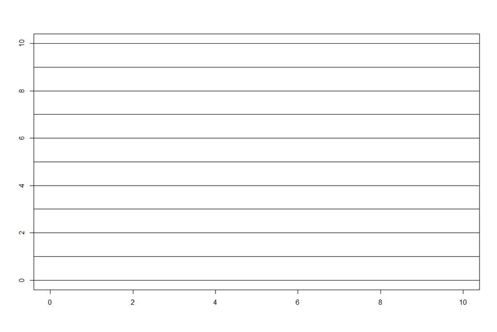

```r
plot(1, type = "n", xlab = "", ylab = "", xlim = c(0,10), ylim = c(0,10))
for (i in 0:10) {
  abline(h = i)
}
```

#### b) Add vertical lines

Extend the previous code, but now also add 11 vertical lines. Show the code and the changed plot in the output.

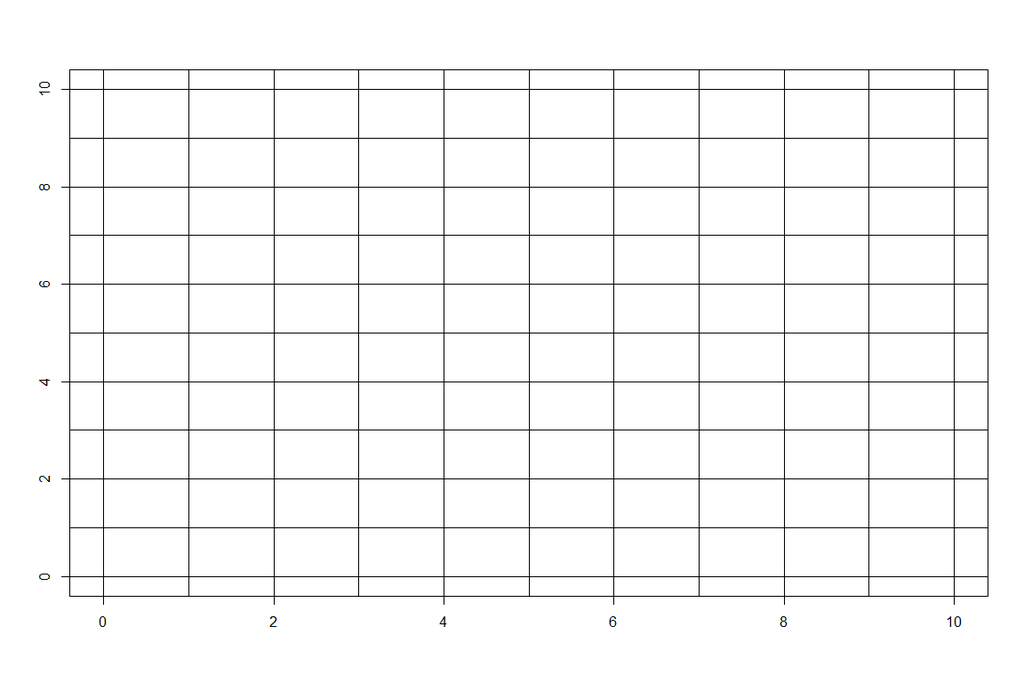

```r
plot(1, type = "n", xlab = "", ylab = "", xlim = c(0,10), ylim = c(0,10))
for (i in 0:10) {
  abline(h = i)
  abline(v = i)
}
```

#### c) Add points

Lastly, add `points()` to the plot to all coordinate points where the lines intersect on the diagonals (that is the 45 and -45 degree lines). E.g. x=1,y=1 … x=1,y=9 etc. Again, show the code and the changed plot output.

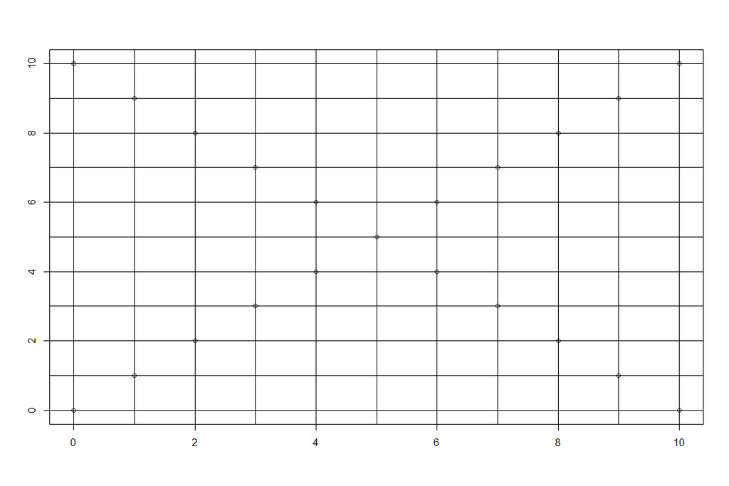

```r
plot(1, type = "n", xlab = "", ylab = "", xlim = c(0,10), ylim = c(0,10))
for (i in 0:10) {
  abline(h = i)
  abline(v = i)
  points(x = i, y = i)
  points(x = i, y = 10-i)
}
```

#### d) Convert to function

Convert this into a function that will allow the user to set the size of the plot (the plot should be square) and which items to draw (horizontal lines, vertical lines, points on the diagonal). Show the function you have written but no other output. Make sure the arguments of the function are set to sensible default values.

```r
square_plot <- function(size = 10, hlines = TRUE, vlines = TRUE, diagonal_point = TRUE) {
  plot(1, type = "n", xlab = "", ylab = "", xlim = c(0,size), ylim = c(0,size))
  for (i in 0:size) {
    if (hlines) {abline(h = i)}
    if (vlines) {abline(v = i)}
    if (diagonal_point) {
      points(x = i, y = i)
      points(x = i, y = size-i)
      }
  }
}
```

I think there is some ambiguity in the ‘diagonal_plot’. Since question 2c defines diagonal points as ‘all coordinate points where the lines intersect on the diagonals’, does it imply that if there is no lines then there should not be points (given it is impossible to have intersections without lines)? If that is the case, please see below for a revised funnction that takes this issue into consideration.

```r
square_plot <- function(size = 10, hlines = TRUE, vlines = TRUE, diagonal_point = TRUE) {
  if ((hlines | vlines) == FALSE & diagonal_point) {print('If there is no lines, there is no points')}
  else {
    plot(1, type = "n", xlab = "", ylab = "", xlim = c(0,size), ylim = c(0,size))
    for (i in 0:size) {
    if (hlines) {abline(h = i)}
    if (vlines) {abline(v = i)}
    if (diagonal_point) {
      points(x = i, y = i)
      points(x = i, y = size-i)
      }
  }
  }
}

square_plot(15, F, F, T)
```

```
## [1] "If there is no lines, there is no points"
```

### Descriptive Statistics of a Vector with Error Checks (**NOT REQUIRED!**)

Write a `desc_stats()` function that calculates some descriptive statistics for a vector.

#### a) Calculate min and max

Write a function that takes a vector as input and prints its minimum and maximum. Make sure to remove any `NA`s from the vector before the calculations.

```r
desc_stats <- function(vector) {
  cat('max:', max(vector, na.rm = TRUE), '\n',
      'min:', min(vector, na.rm = TRUE))
}
```

#### b) Add the median

Add an additional argument to the function (set to `FALSE` by default) that will allow a user to calculate the median of the vector as well. If the median is calculated, round it to two digits (hint: use the function `round()`).

```r
desc_stats <- function(vector, median = FALSE) {
  if (median) {
    cat('max:', max(vector, na.rm = TRUE), '\n',
        'min:', min(vector, na.rm = TRUE), '\n',
        'median:', median(vector, na.rm = FALSE), '\n')
  } else {
    cat('max:', max(vector, na.rm = TRUE), '\n',
        'min:', min(vector, na.rm = TRUE))
  }
}
```

#### c) Add error checks

Try your function on an empty vector `z1 <- c()` and a vector containing only `NA`s. You probably get a rather cryptic error.Alter your function so that it stops when a user supplies an empty vector or a vector with only `NA`s and gives a short warning about the issue.

```r
desc_stats <- function(vector, median = FALSE) {
  if (length(vector) == 0) {
    return('Input vector should not be empty')
  }

  if (all(is.na(vector))) {
    return('Input vector should have at least one non-NA element')
  }
  if (median) {
    cat('max:', max(vector, na.rm = TRUE), '\n',
        'min:', min(vector, na.rm = TRUE), '\n',
        'median:', median(vector, na.rm = FALSE), '\n')
  } else {
    cat('max:', max(vector, na.rm = TRUE), '\n',
        'min:', min(vector, na.rm = TRUE))
  }
}
```